# R Notebook

# Análisis Probabilístico

Se analizarán en forma probabilística las variables relevantes del estudio, recordemos que estamos trabajando con probabildades *a priori*

## Días de falta de sueño a causa de problemas con la salud mental

- Tipo de variable aleatoria: **Discreta**
- Distribución escogida: **Binomial**

Para analizar esta variable nos puede resultar útil conocer las probabilidades de no poder dormir entre los 7 días de la semana a causa de problemas psicológicos como ansiedad, depresión, o estrés. A fin de conocer cómo son las probabilidades, se utilizó un diagrama de barras graficando las frecuencias relativas en base a la tabla de frecuencias de los días de falta de sueño utilizando el comando `prop.table`.

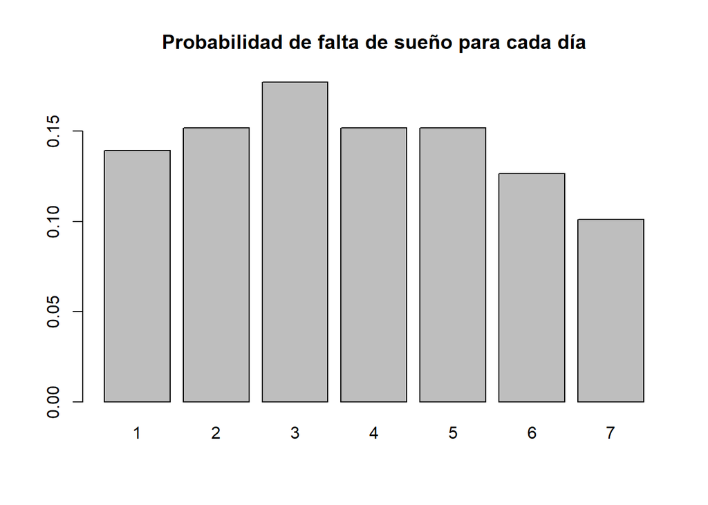

Información obtenida por el gráfico

```
Del gráfico podemos conocer que es más probable que un estudiante que posea problemas con salud mental no pueda dormir 3 días  a causa de este problema.
```

Para realizar un análisis de esta variable en término de distribución de probabilidaes podríamos analizar el siguiente caso:

**¿Cuál será la probabilidad de que 40 estudiantes no puedan conciliar un día de sueño?**

- Experimento: Preguntarle a una persona si debido a problemas con la salud mental no logra dormir.
- Éxito: Que la persona diga que no puede dormir.
- Variable Aleatoria Discreta: Cantidad de días sin poder conciliar el sueño a causa de la salud mental

Para conocer la probabilidad de éxito, podemos utilizar una tabla de frecuencias o una tabla de frecuencias relativas

```
##
##         1         2         3         4         5         6         7
## 0.1392405 0.1518987 0.1772152 0.1518987 0.1518987 0.1265823 0.1012658
```

```
## [1] 8.738195e-15
```

Distribución binomial para cada un estudiante desde 1 hasta 79, para ello se utilizará la función `plot`

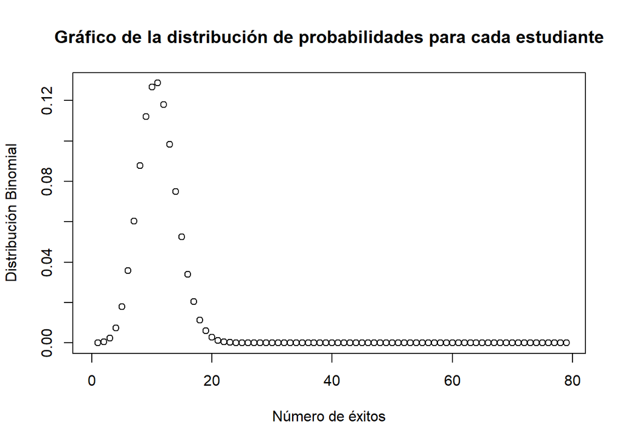

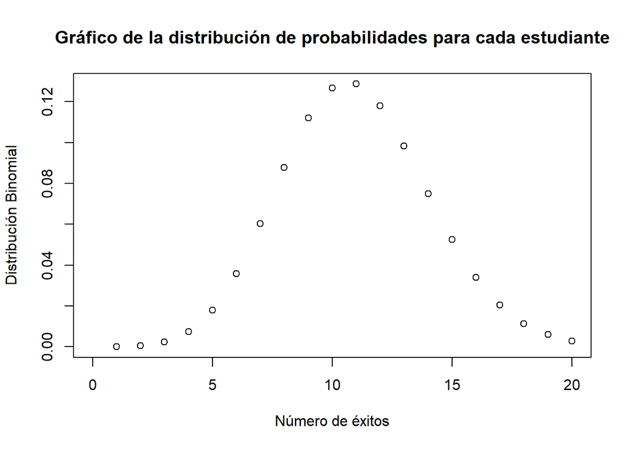

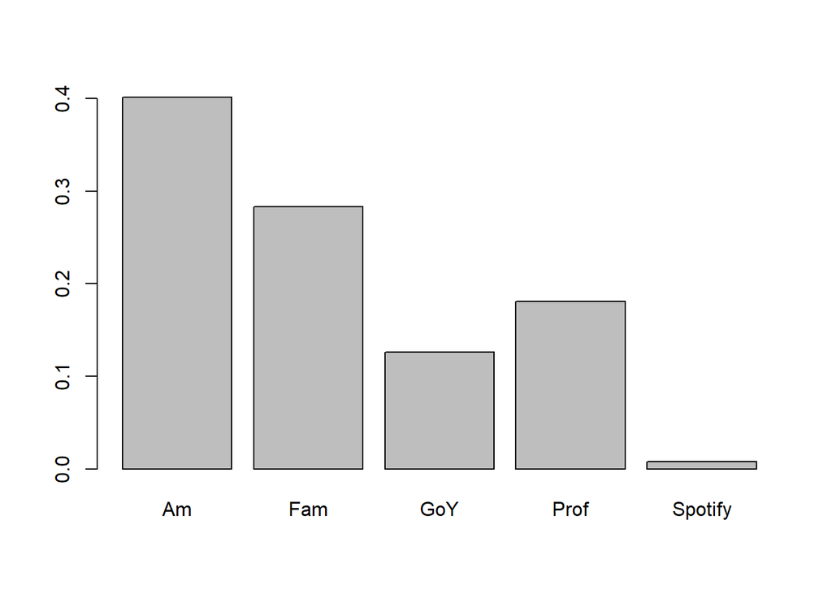

Información obtenida por el gráfico

```
Del gráfico de barras ahora podemos determinar que los estudiantes tienden a acudir más a sus amigos que sus familiares, la web o un profesional
```

Para el complementar con el análisis podemos evaluar el siguiente caso

- Experimento: Preguntarle a une estudiante si frente algún problema acude a sus amigos
- Éxito: Qué diga que sí acude
- variable aleatoria: Número de estudiantes que acuden a sus amigos

Para conocer la probabilidad de éxito se puede hacer una tabla de frecuencias relativas en base a la tabla de frecuencias utilizando la función `prop.table`

```
## FSE
##          Am         Fam         GoY        Prof     Spotify
## 0.401574803 0.283464567 0.125984252 0.181102362 0.007874016
```

```r
r <- 40
x <- 39
p <- 0.401574803
dnbinom(x,r,p)
```

```
## [1] 0.007742544
```

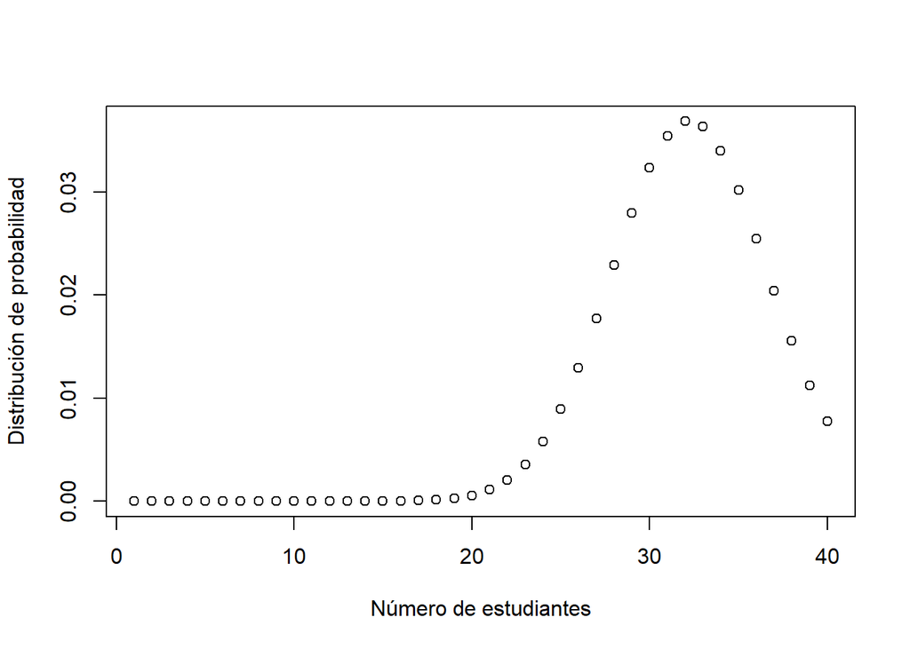

## Apoyo personal hacia los estudiantes y Días de falta de sueño

Resulta interesante también conocer si ambas variables **Apoyo personal hacia los estudiantes** y **Días de falta de sueño** presentan un comportamiento notable que se pueda analizar de forma probabilística. Con esa finalidad buscamos conocer las probabilidades de un caso de pares y para ello se usará la función `prop.table` que nos dirá la tabla de frecuencias relativas en base a la table de frecuencias que presenten ambas variables.

```
##
##            1  2  3  4  5  6  7
##   No       0  0  0  2  2  0  0
##   Si       9 11 10  7  7  7  6
##   Tal vez  2  1  3  2  3  3  2
```

```
##
##                    1          2          3          4          5          6
##   No      0.00000000 0.00000000 0.00000000 0.02597403 0.02597403 0.00000000
##   Si      0.11688312 0.14285714 0.12987013 0.09090909 0.09090909 0.09090909
##   Tal vez 0.02597403 0.01298701 0.03896104 0.02597403 0.03896104 0.03896104
##
##                    7
##   No      0.00000000
##   Si      0.07792208
##   Tal vez 0.02597403
```

Ahora para finalizar se analizará el último caso

**Cuál es la probabilidad de que de un grupo de 20 estudiantes que sí recibe apoyo se encuentre a uno que no pueda lograr dormir 7 días** + Experimento: Preguntarle a un estudiante que reciba apoyo si no puede dormir entre 1 a 7 días a causa de problemas psicológicos + Éxito: Que el estudiante responda que no puede + variable aleatoria: Cantidad de días que no pueden dormir a causa de problemas de salud mental

```r
p<-0.07792208
x<-19
dgeom(19,p)
```

```
## [1] 0.01668189
```

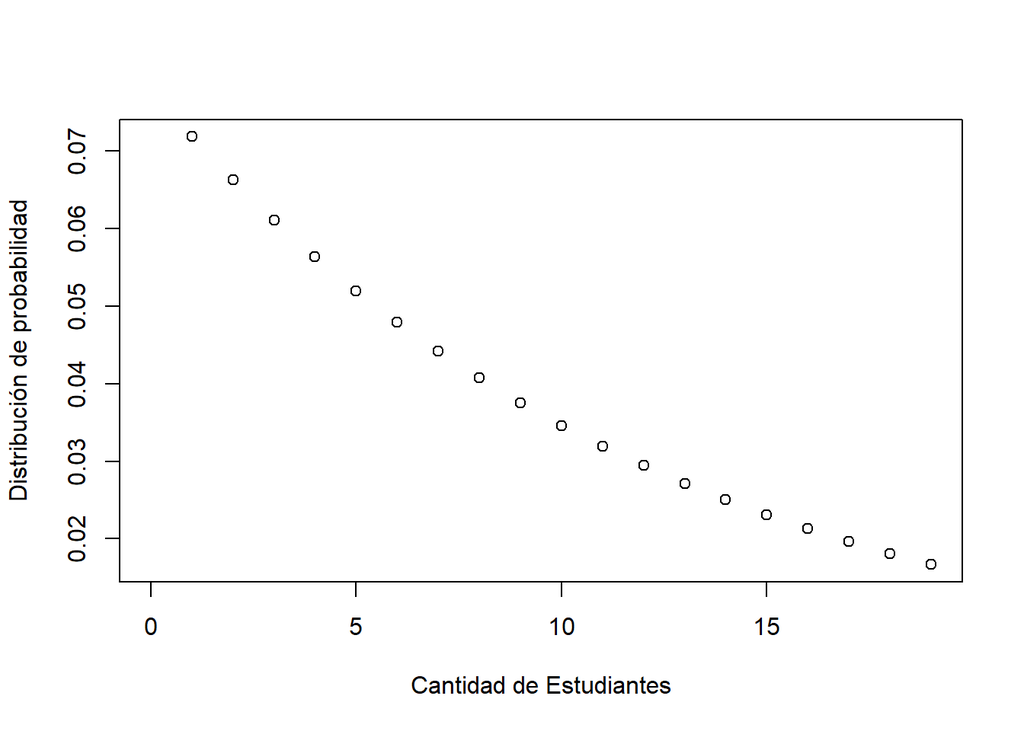